Care-team report · generated by 5 AI personas · synthetic scenario 'af_pneumonia'

# James Carter

71 · Male · BMI 26.5 · BP 128/80 · temp 38.6°C · SpO₂ 93%

SAME DAY - see a clinician in person today

This report was produced by an educational multi-agent software demo using synthetic or public de-identified data. It is not medical advice. Diagnoses and prescriptions are drafts that a licensed clinician must review before anything is acted on.

MD

## What it all means

Doctor — integrates every result

“Putting all the results together, the main issues are: chest infection (pneumonia), atrial fibrillation (irregular heartbeat), high cholesterol / heart risk, possible heart weakness or strain. Recommended timing: see a clinician in person today. I've drafted 4 medicine(s) and 0 change(s) to your current medicines for your doctor to review.”

### Chest infection (pneumonia)

Community-acquired pneumonia, right lower lobe · *likely*

A bacterial infection in part of the lung. Most people recover fully with antibiotics, rest and fluids over 1-3 weeks; tiredness and cough can last longer.

### Atrial fibrillation (irregular heartbeat)

Atrial fibrillation with rapid ventricular response · *likely (confirm on 12-lead ECG)*

The heart's upper chambers beat chaotically. The two goals are to keep the heart rate comfortable and to prevent blood clots that can cause a stroke. A chest infection can trigger AF; it may settle as the infection clears.

### High cholesterol / heart risk

Dyslipidaemia (LDL 118) · *confirmed*

Extra cholesterol can build up in arteries. Lowering it cuts the chance of heart attack and stroke.

### Possible heart weakness or strain

Suspected heart failure (needs echocardiogram) · *possible*

Some tests suggest your heart may be working harder than it should. An ultrasound of the heart (echo) will show whether this is heart failure. Atrial fibrillation and the chest infection can also cause these results.

### Medicines (draft)

#### Levofloxacin 750 mg

once daily · 5 days

**Why:** Antibiotic to treat the lung infection

**How:** Take at the same time each day with water. Keep 2 hours apart from iron, calcium, magnesium supplements and antacids.

**Watch for:** Upset stomach, dizziness; rarely tendon pain (stop and call), blood sugar swings.

#### Acetaminophen (paracetamol) 500-1000 mg

every 6 hours if needed · while fever/aches last

**Why:** Fever and aches

**How:** Do not exceed 3,000 mg in 24 hours. Check other medicines for hidden acetaminophen.

**Watch for:** Rare at normal doses.

#### Metoprolol succinate 25 mg

once daily · ongoing, review in 1-2 weeks

**Why:** Slows the heart rate so it pumps more efficiently

**How:** Swallow whole; do not stop suddenly.

**Watch for:** Tiredness, dizziness, cold hands.

#### Apixaban 5 mg

twice daily · long-term

**Why:** Thins the blood to lower stroke risk from AF

**How:** Take every 12 hours; don't skip doses. Tell any dentist or surgeon you take it.

**Watch for:** Easier bruising; seek help for black stools, blood in urine or vomit.

### Tests

- Repeat chest X-ray in 6-8 weeks if over 50 or smoker, to confirm clearing
- Pulse oximetry at review
- 12-lead ECG to confirm AF
- Echocardiogram
- 10-year cardiovascular risk calculation (PREVENT) to decide on a statin

### Referrals & follow-up

- Cardiology (AF clinic) within 2-4 weeks
- Follow-up: 48-72 hours (infection check), then 2 weeks

LA

## Your test results

Lab Analyst — blood, urine & EKG

“I checked 21 blood and urine results; 7 were outside the usual range. Your blood sugar is a little higher than ideal. This is called prediabetes and can often be reversed with food and activity changes. Your cholesterol and blood-fat levels are higher than recommended, which over years raises the risk of heart attack and stroke. Your blood shows signs that your body is fighting an infection. A blood marker of heart strain is raised. It can rise with heart, kidney or rhythm problems, so your heart needs a closer look. Your heartbeat is irregular in a pattern called atrial fibrillation (AF): the top chambers quiver instead of beating in step. AF is common and treatable, but it raises stroke risk, so it needs treatment.”

| Test | Result | Usual |  |
| --- | --- | --- | --- |
| **Fasting glucose** blood sugar | 118 mg/dL | 70-99 | High |
| **HbA1c** 3-month average blood sugar | 5.8 % | 4.0-5.6 | High |
| **Total cholesterol** total cholesterol | 198 mg/dL | 0-199 | Normal |
| **LDL cholesterol** 'bad' cholesterol | 118 mg/dL | 0-99 | High |
| **HDL cholesterol** 'good' cholesterol | 46 mg/dL | >40 | Normal |
| **Triglycerides** blood fats | 150 mg/dL | 0-149 | High |
| **Creatinine** kidney waste marker | 1.1 mg/dL | 0.6-1.3 | Normal |
| **BUN** urea (kidney marker) | 18 mg/dL | 7-20 | Normal |
| **ALT** liver enzyme | 30 U/L | 7-40 | Normal |
| **AST** liver enzyme | 28 U/L | 10-40 | Normal |
| **Hemoglobin** oxygen-carrying red cell protein | 14.0 g/dL | 13.5-17.5 | Normal |
| **MCV** red blood cell size | 90 fL | 80-100 | Normal |
| **White cell count** infection-fighting cells | 15.8 x10^9/L | 4.0-11.0 | High |
| **Platelets** clotting cells | 310 x10^9/L | 150-400 | Normal |
| **CRP** inflammation marker | 96 mg/L | 0-10 | High |
| **Potassium** potassium | 4.0 mmol/L | 3.5-5.0 | Normal |
| **Sodium** salt balance | 136 mmol/L | 135-145 | Normal |
| **TSH** thyroid signal | 1.8 mIU/L | 0.4-4.5 | Normal |
| **Ferritin** iron stores | 210 ng/mL | 30-400 | Normal |
| **NT-proBNP** heart strain marker | 450 pg/mL | 0-125 | High |
| **Vitamin B12** vitamin B12 | 380 pg/mL | 200-900 | Normal |

Kidney filtration (eGFR): **72** · stage G2

### Heart tracing (EKG, lead II)

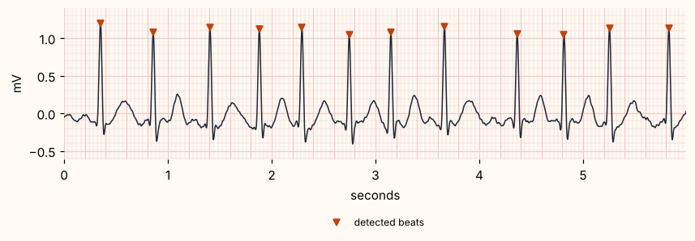

**124**beats/min

**Atrial fibrillation**rhythm

**45%**beats with P wave

**0.179**beat-to-beat variability

**88 ms**QRS width

RX

## Your chest X-ray

Radiologist — imaging

“There is a cloudy patch in the lower part of your right lung. Together with fever and cough, this usually means a chest infection (pneumonia).”

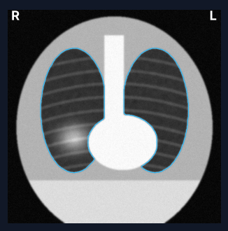

**Impression:** focal opacity right lower lobe

**Heart-to-chest ratio:** 0.47 (normal ≤ 0.50)

Automated heuristic read; must be confirmed by a radiologist.

RD

## Your eating plan

Nutritionist — food & medicine

“Your eating plan aims for about 2200 calories a day to maintain weight while recovering (illness raises energy needs). Fill half the plate with non-starchy vegetables, a quarter with protein, a quarter with whole grains. Use olive oil instead of butter, eat oily fish twice a week (or walnuts/flax if vegetarian), aim for 25-30 g fibre a day (oats, beans, vegetables). Cook from scratch, taste before salting, use herbs, lemon, garlic and spices.”

**2200**kcal / day

**84 g**protein

**272 g**carbs

**86 g**fat

**<2000 mg**sodium

Goal: maintain weight while recovering (illness raises energy needs)

#### Blood sugar

Fill half the plate with non-starchy vegetables, a quarter with protein, a quarter with whole grains. Spread carbs evenly over 3 meals. Swap sugary drinks for water.

Why: Steady carbs avoid sugar spikes; fibre slows sugar absorption.

#### Cholesterol

Use olive oil instead of butter, eat oily fish twice a week (or walnuts/flax if vegetarian), aim for 25-30 g fibre a day (oats, beans, vegetables). Limit fried foods, pastries and processed meats.

Why: Soluble fibre and unsaturated fats lower LDL and triglycerides.

#### Salt

Cook from scratch, taste before salting, use herbs, lemon, garlic and spices. Check labels: under 400 mg sodium per serving is a good rule.

Why: Less salt lowers blood pressure and fluid build-up.

#### While you're unwell

Drink regularly - aim for pale yellow urine (about 2 L a day unless your doctor limits fluids). Small, soft, frequent meals are fine if your appetite is low. Soups, eggs, yogurt and fruit are good choices.

Why: Fever and fast breathing increase fluid loss.

### A sample day

| Breakfast | Steel-cut oats with walnuts, cinnamon and a few blueberries ~380 kcal or: Cream of wheat (iron-fortified) made with water, topped with apple slices |
| --- | --- |
| Lunch | Lentil and vegetable soup with a side salad ~450 kcal or: Tuna and white-bean salad on mixed greens |
| Dinner | Baked salmon, green beans and 1/2 cup brown rice ~540 kcal or: Chicken breast, cauliflower mash and steamed broccoli |
| Snack | Apple slices with 1 tbsp almond butter ~190 kcal or: A small handful of unsalted almonds |

### Food & medicine tips

- Antibiotic: keep dairy, calcium, iron and antacids at least 2 hours away from each dose.
- Avoid large amounts of grapefruit or grapefruit juice (raises levels of apixaban).
- Apixaban: no need to restrict vitamin K foods (unlike warfarin); avoid heavy alcohol.

PT

## Your movement plan

Physiotherapist — safe exercise

“First, active chest infection/fever: no structured exercise until fever-free for 48-72 h and breathing is comfortable. Gentle breathing exercises and short walks indoors only. For now your activity level is 'recovery', about 9-10 (very light) on the effort scale (talk test: you can sing.) Breathing exercises 3x/day; sit out of bed and walk around the house for 2-5 minutes every 1-2 hours while awake.”

**recovery**effort level

**9-10 (very light)**effort scale (6-20)

**You can sing.**talk test

Active chest infection/fever: no structured exercise until fever-free for 48-72 h and breathing is comfortable. Gentle breathing exercises and short walks indoors only.

Resting heart rate 124: keep to light activity until the heart rate is controlled (resting < 100-110).

Possible heart strain: light activity only until the echo is done; avoid heavy lifting and breath-holding.

1. **While unwell:** Breathing exercises 3x/day; sit out of bed and walk around the house for 2-5 minutes every 1-2 hours while awake.
2. **Fever-free 48-72 h:** Walks of 5-10 minutes once or twice daily, flat ground.
3. **Weeks 2-4 after recovery:** Build to 20-30 minute walks, 5 days a week; add the strength routine twice a week.

**Mon**Breathing exercises 3xShort indoor walks every 1-2 h

**Tue**Breathing exercises 3xShort indoor walks every 1-2 h

**Wed**Breathing exercises 3xShort indoor walks every 1-2 h

**Thu**Breathing exercises 3xShort indoor walks every 1-2 h

**Fri**Breathing exercises 3xShort indoor walks every 1-2 h

**Sat**Breathing exercises 3xShort indoor walks every 1-2 h

**Sun**Breathing exercises 3xShort indoor walks every 1-2 h

### Strength routine

- Sit-to-stand from a chair — 1 set x 8-12
- Wall push-ups — 1 set x 8-12
- Standing calf raises (hold the counter) — 1 set x 10-15
- Resistance-band rows — 1 set x 10-12
- Glute bridge (on bed or floor) — 1 set x 10

### Breathing exercises

- Pursed-lip breathing — in through nose 2 counts, out through pursed lips 4 counts, 5 min
- Deep breathing with 3-second hold, then a supported cough — 5 breaths, 3x/day

### Balance

- Heel-to-toe standing at the counter — 3 x 20 s
- Single-leg stand, hand on counter — 3 x 15 s each
- You'll be on a blood thinner: avoid contact sports and activities with high fall risk.
- Heart-rate targets aren't reliable for you right now (heart rhythm, medicine or a fast resting rate), so use the effort scale and talk test instead.

**Stop and rest if you notice:** Chest pain, pressure or tightness; Severe breathlessness or wheezing that doesn't settle with rest; Dizziness, light-headedness or fainting; Heart racing or pounding irregularly beyond your usual; Unusual sweating, nausea or confusion.

## Get help urgently if

- Breathing becomes hard or lips turn blue
- Confusion or drowsiness
- Fever not improving after 48-72 hours of antibiotics
- Chest pain or fainting
- Sudden weakness, face drooping or speech trouble (call 911)
- Heart racing with breathlessness at rest
- Breathless lying flat or waking up gasping
- Weight gain > 2 kg in 3 days

### Questions to ask your doctor

- How will I know the antibiotic is working, and when should I call if it isn't?
- What heart rate should I aim for, and how long will I need the blood thinner?
- What cholesterol level are we aiming for?
- When is my heart ultrasound, and what should I watch for until then?

**For clinicians: safety checks, risk scores and agent trace**

**Risk scores:** {"CHA2DS2-VASc": 2, "CURB-65": 1}

- Levofloxacin: penicillin allergy -> beta-lactam avoided, respiratory fluoroquinolone chosen
- Levofloxacin: CrCl 73.0 mL/min -> no renal adjustment
- Levofloxacin: QT prolongation risk noted: obtain 12-lead ECG QTc before first dose
- Acetaminophen (paracetamol): NSAIDs avoided (anticoagulant planned)
- Metoprolol succinate: resting HR 124 > 110 -> rate control indicated
- Metoprolol succinate: low starting dose; titrate to resting HR < 110
- Apixaban: CHA2DS2-VASc 2 (threshold 2) -> anticoagulation indicated
- Apixaban: dose-reduction criteria met: 0/3 -> 5 mg
- Apixaban: no strong CYP3A4/P-gp inhibitor prescribed (clarithromycin avoided)
- Apixaban: NSAIDs and aspirin to be avoided

**Team huddle:**

- No conflicts between agents.

**Trace:**

1. Care team convened for James Carter [synthetic scenario 'af_pneumonia'] - narration: offline rule engine
2. Stage 1: Lab Analyst || Radiologist
3. [Lab Analyst] starting
4. [Radiologist] starting
5. [Lab Analyst] done: 5 findings, 0 recommendations
6. [Radiologist] done: 1 findings, 0 recommendations
7. Stage 1 finished in 0.36s
8. Stage 2: Doctor
9. [Doctor] starting
10. [Doctor] done: 4 findings, 4 recommendations
11. Stage 2 finished in 0.00s
12. Stage 3: Nutritionist || Physiotherapist
13. [Nutritionist] starting
14. [Nutritionist] done: 1 findings, 0 recommendations
15. [Physiotherapist] starting
16. [Physiotherapist] done: 1 findings, 0 recommendations
17. Stage 3 finished in 0.00s
18. [Huddle] No conflicts between agents.